# What is the future selling price of a home?

# Table of Contents

## Introduction

### A few words on the dataset

In this notebook we developped a full-fledged approach to make predictions about the future sale prices of homes in the city of Ames, Iowa.

The prediction of the final price of each home will be made based on a dataset that includes 79 explanatory variables describing (almost) every aspect of residential homes in a small city in the US.

Indeed, if you ask a home buyer to describe their dream house, he probably wouldn't begin with describing features such as the height of the basement ceiling or the proximity to a railroad. The dataset we use here takes into consideration realistic features that influence price negotiations such the number of bedrooms or a swimming-pool.

The files we were given are as follows:

- train.csv - the training dataset
- test.csv - the test dataset
- data_description.txt - full description of each column

### Goals

As our goal is to predict the price of each house of a town using the dataset we were given we have to follow some steps.

The basic steps are as followed:

- Descriptive statistics on the data
- Data cleaning and pre-processing
- Defining a modeling approach to the problem
- Build such a model
- Validate the outcome of the model

In order to evaluate our model we also have to use different metrics in order for example to take into account that errors in predicting expensive houses and cheap houses don't affect the result equally.

```python
!pip install -q gmaps
!pip install -q googlemaps
#!jupyter nbextension enable --py --sys-prefix gmaps
```

```python
import numpy as np
import pandas as pd
import matplotlib.pyplot as plt
import seaborn as sns
import warnings

sns.set(palette=sns.color_palette("Blues"), font_scale=1.5)
sns.despine(offset=10, trim=True)
warnings.filterwarnings("ignore")
```

```python
training_data = pd.read_csv("challenge_data/train.csv")
training_data[:5]
```

|  | Id | MSSubClass | MSZoning | LotFrontage | LotArea | Street | Alley | LotShape | LandContour | Utilities | ... | PoolArea | PoolQC | Fence | MiscFeature | MiscVal | MoSold | YrSold | SaleType | SaleCondition | SalePrice |
| --- | --- | --- | --- | --- | --- | --- | --- | --- | --- | --- | --- | --- | --- | --- | --- | --- | --- | --- | --- | --- | --- |
| 0 | 1 | 60 | RL | 65.0 | 8450 | Pave | NaN | Reg | Lvl | AllPub | ... | 0 | NaN | NaN | NaN | 0 | 2 | 2008 | WD | Normal | 208500 |
| 1 | 2 | 20 | RL | 80.0 | 9600 | Pave | NaN | Reg | Lvl | AllPub | ... | 0 | NaN | NaN | NaN | 0 | 5 | 2007 | WD | Normal | 181500 |
| 2 | 3 | 60 | RL | 68.0 | 11250 | Pave | NaN | IR1 | Lvl | AllPub | ... | 0 | NaN | NaN | NaN | 0 | 9 | 2008 | WD | Normal | 223500 |
| 3 | 4 | 70 | RL | 60.0 | 9550 | Pave | NaN | IR1 | Lvl | AllPub | ... | 0 | NaN | NaN | NaN | 0 | 2 | 2006 | WD | Abnorml | 140000 |
| 4 | 5 | 60 | RL | 84.0 | 14260 | Pave | NaN | IR1 | Lvl | AllPub | ... | 0 | NaN | NaN | NaN | 0 | 12 | 2008 | WD | Normal | 250000 |

5 rows × 81 columns

```python
# Look at the columns headers
print("Column list ({} columns):".format(len(training_data.columns)))
print(",\t".join(training_data.columns.tolist()))
```

```
Column list (81 columns):
Id,	MSSubClass,	MSZoning,	LotFrontage,	LotArea,	Street,	Alley,	LotShape,	LandContour,	Utilities,	LotConfig,	LandSlope,	Neighborhood,	Condition1,	Condition2,	BldgType,	HouseStyle,	OverallQual,	OverallCond,	YearBuilt,	YearRemodAdd,	RoofStyle,	RoofMatl,	Exterior1st,	Exterior2nd,	MasVnrType,	MasVnrArea,…
```

```python
training_data._get_numeric_data().info()
```

```
<class 'pandas.core.frame.DataFrame'>
RangeIndex: 1200 entries, 0 to 1199
Data columns (total 38 columns):
Id               1200 non-null int64
MSSubClass       1200 non-null int64
LotFrontage      990 non-null float64
LotArea          1200 non-null int64
OverallQual      1200 non-null int64
OverallCond      1200 non-null int64
YearBuilt        1200 non-null int64
YearRemodAdd     1200 non-null int64
MasVnrArea       1194 non-null float64
BsmtFinSF1       1200 non-null int64
BsmtFinSF2       1200 non-null int64
BsmtUnfSF        1200 non-null int64
TotalBsmtSF      1200 non-null int64
1stFlrSF         1200 non-null int64
2ndFlrSF         1200 non-null int64
LowQualFinSF     1200 non-null int64
GrLivArea        1200 non-null int64
BsmtFullBath     1200 non-null int64
BsmtHalfBath     1200 non-null int64
FullBath         1200 non-null int64
HalfBath         1200 non-null int64
BedroomAbvGr     1200 non-null int64
KitchenAbvGr     1200 non-null int64
TotRmsAbvGrd     1200 non-null int64
Fireplaces       1200 non-null int64
GarageYrBlt      1133 non-null float64
GarageCars       1200 non-null int64
GarageArea       1200 non-null int64
WoodDeckSF       1200 non-null int64
OpenPorchSF      1200 non-null int64
EnclosedPorch    1200 non-null int64
3SsnPorch        1200 non-null int64
ScreenPorch      1200 non-null int64
PoolArea         1200 non-null int64
MiscVal          1200 non-null int64
MoSold           1200 non-null int64
YrSold           1200 non-null int64
SalePrice        1200 non-null int64
dtypes: float64(3), int64(35)
memory usage: 356.3 KB
```

```python
training_data.describe()
```

|  | Id | MSSubClass | LotFrontage | LotArea | OverallQual | OverallCond | YearBuilt | YearRemodAdd | MasVnrArea | BsmtFinSF1 | ... | WoodDeckSF | OpenPorchSF | EnclosedPorch | 3SsnPorch | ScreenPorch | PoolArea | MiscVal | MoSold | YrSold | SalePrice |
| --- | --- | --- | --- | --- | --- | --- | --- | --- | --- | --- | --- | --- | --- | --- | --- | --- | --- | --- | --- | --- | --- |
| count | 1200.000000 | 1200.000000 | 990.000000 | 1200.000000 | 1200.000000 | 1200.000000 | 1200.000000 | 1200.000000 | 1194.000000 | 1200.000000 | ... | 1200.000000 | 1200.000000 | 1200.000000 | 1200.000000 | 1200.000000 | 1200.000000 | 1200.000000 | 1200.000000 | 1200.000000 | 1200.000000 |
| mean | 600.500000 | 57.075000 | 70.086869 | 10559.411667 | 6.105000 | 5.568333 | 1971.350833 | 1984.987500 | 103.962312 | 444.886667 | ... | 95.136667 | 46.016667 | 22.178333 | 3.653333 | 14.980833 | 1.909167 | 40.453333 | 6.311667 | 2007.810833 | 181414.628333 |
| std | 346.554469 | 42.682012 | 23.702029 | 10619.135549 | 1.383439 | 1.120138 | 30.048408 | 20.527221 | 183.534953 | 439.987844 | ... | 124.034129 | 65.677629 | 61.507323 | 29.991099 | 54.768057 | 33.148327 | 482.323444 | 2.673104 | 1.319027 | 81070.908544 |
| min | 1.000000 | 20.000000 | 21.000000 | 1300.000000 | 1.000000 | 1.000000 | 1875.000000 | 1950.000000 | 0.000000 | 0.000000 | ... | 0.000000 | 0.000000 | 0.000000 | 0.000000 | 0.000000 | 0.000000 | 0.000000 | 1.000000 | 2006.000000 | 34900.000000 |
| 25% | 300.750000 | 20.000000 | 59.000000 | 7560.000000 | 5.000000 | 5.000000 | 1954.000000 | 1967.000000 | 0.000000 | 0.000000 | ... | 0.000000 | 0.000000 | 0.000000 | 0.000000 | 0.000000 | 0.000000 | 0.000000 | 5.000000 | 2007.000000 | 129900.000000 |
| 50% | 600.500000 | 50.000000 | 70.000000 | 9434.500000 | 6.000000 | 5.000000 | 1973.000000 | 1994.000000 | 0.000000 | 385.500000 | ... | 0.000000 | 24.000000 | 0.000000 | 0.000000 | 0.000000 | 0.000000 | 0.000000 | 6.000000 | 2008.000000 | 163700.000000 |
| 75% | 900.250000 | 70.000000 | 80.000000 | 11616.000000 | 7.000000 | 6.000000 | 2000.000000 | 2004.000000 | 166.750000 | 712.250000 | ... | 168.000000 | 68.000000 | 0.000000 | 0.000000 | 0.000000 | 0.000000 | 0.000000 | 8.000000 | 2009.000000 | 214000.000000 |
| max | 1200.000000 | 190.000000 | 313.000000 | 215245.000000 | 10.000000 | 9.000000 | 2010.000000 | 2010.000000 | 1600.000000 | 2260.000000 | ... | 857.000000 | 523.000000 | 552.000000 | 508.000000 | 410.000000 | 648.000000 | 15500.000000 | 12.000000 | 2010.000000 | 755000.000000 |

8 rows × 38 columns

```python
# Check if all data got an Id
training_data.Id.count() == len(training_data)
```

```
True
```

## Data Cleaning

### Replace Object to Categorical data

For sake of faster computation, we chose to convert object types which are enumerations of string elements to categorical data, for which the computation is way faster in pandas.

```python
def object_to_cat(col):
    """
        Returns col as type category if col is object else return object
    """
    if col.dtype == object:
        return col.astype('category')
    else:
        return col
```

```python
training_data = training_data.apply(object_to_cat, axis=0)
# Show a small subset of types
training_data.dtypes[:10]
```

```
Id                int64
MSSubClass        int64
MSZoning       category
LotFrontage     float64
LotArea           int64
Street         category
Alley          category
LotShape       category
LandContour    category
Utilities      category
dtype: object
```

## Data visualisation

The thing is here to compare and approximate the price for houses, located in different areas/neighborhoods. Is it therefore important to have a look at those locations in order to see whether or not there is a correlation between some areas and prices.

### Plotting data on maps

```python
#http://jupyter-gmaps.readthedocs.io/en/latest/
import gmaps
import googlemaps

gmaps_api_key = "AIzaSyDvvmIy3QADjvFFtiYrTS1lEz3kDa8vnTo"

gmaps_api = googlemaps.Client(key=gmaps_api_key)
gmaps.configure(api_key=gmaps_api_key)

def location_to_gps(loc_string):
    """
        Returns a (location string, google location data) tuple.
    """
    # Please note that the dataset is based on Ames, IOWA data.
    return (loc_string,gmaps_api.geocode(loc_string + ", Ames, IOWA"))
```

```python
locations = list(training_data.Neighborhood.unique())
```

```python
# Get the location data from the google api

geocodedLocations = filter(
    # Remove unknown locations
    lambda x: x[1]!= [],

    # Use the following line instead of the above one to delete uncertain locations
    #lambda x: x!= [] and len(x) == 1,

    # find locations
    map(location_to_gps, locations)
)
```

```python
# Extract latitude and longitude
geocodedLocations_lnglat = {
    # Keys are plain tex neighborhood names, values the (lat, lng) tuples
    x[0]: tuple(x[1][0]["geometry"]["location"].values())
    for x in geocodedLocations
}
```

```python
print("{} not found locations!".format(len(locations) - len(geocodedLocations_lnglat)))
```

```
0 not found locations!
```

```
fig = gmaps.figure()
markers = gmaps.marker_layer(geocodedLocations_lnglat.values())
fig.add_layer(markers)
fig
```

[figure not shown]

The first think we can mention is that the different neighborhoods are close to each other, therefore is it accurate to compare spacialy the houses.

```python
def get_latitude(neighborhood):
    return geocodedLocations_lnglat.get(neighborhood, (0., 0.))[0]
def get_longitude(neighborhood):
    return geocodedLocations_lnglat.get(neighborhood, (0., 0.))[1]
```

#### Heatmap of number of houses sold by neighborhood

Plot a heatmap of the number of houses sold by neighborhood

```python
# Count the sold house by neighborhood
sellsCountHeatMap = (
    training_data[["Neighborhood", "Id"]]
        .groupby("Neighborhood")
        .agg("count")
).reset_index()

# Add latitude and longitude
sellsCountHeatMap["latitude"] = sellsCountHeatMap.apply(lambda x: get_latitude(x.Neighborhood) , axis=1)
sellsCountHeatMap["longitude"] = sellsCountHeatMap.apply(lambda x: get_longitude(x.Neighborhood), axis=1)

# Remove the not found locations
sellsCountHeatMap = sellsCountHeatMap[sellsCountHeatMap.latitude != 0]

# Change the name of the counter
sellsCountHeatMap.columns = [{"Id": "count"}.get(col, col) for col in sellsCountHeatMap.columns]

# Have a look at the results
print(sellsCountHeatMap[:5])
```

```
  Neighborhood  count   latitude  longitude
0      Blmngtn     15  42.056373 -93.644666
1      Blueste      2  42.023090 -93.663783
2       BrDale     12  42.033715 -93.611455
3      BrkSide     45  42.028950 -93.629748
4      ClearCr     25  42.030781 -93.631913
```

```
fig = gmaps.figure()
heatmap_layer = gmaps.heatmap_layer(
    sellsCountHeatMap[['latitude', 'longitude']],
    weights=sellsCountHeatMap['count'],
    max_intensity=float(sellsCountHeatMap["count"].max()),
    point_radius=30.0
)
fig.add_layer(heatmap_layer)
fig
```

[figure not shown]

The above heatmap let us vizualize the concentration of houses sold. Indeed it is important as the price may increase with the demand. Here there are more houses sold in the center of Ames which means that the center is an area of interest and therefore of demand, it is probably more likely that a great proportion of the housing is located in the center of the town.  
If we follow the pure economical pattern of inference based on the offer and demand, we may assume that the price in the center could be greater than in the other area.

#### Heatmap of mean house prices by neighborhood

Generally, most-desired neighborhoods tend to have certain community attributes that are separate from individual home attributes. Some of these attributes might include a good school district, trendy restaurants, parks, etc. Given that we have no information about these attributes, how might the most-desired neighborhoods be reflected in our dataset? We can vizualize it with a heatmap.

Plot a heatmap of the mean price of houses sold by neighborhood

```python
# Compute the mean of houses prices by neighborhood
meanPriceHeatMap = (
    training_data[["Neighborhood", "SalePrice"]]
        .groupby("Neighborhood")
        .agg("mean")
).reset_index()

# Add latitude and longitude
meanPriceHeatMap["latitude"] = meanPriceHeatMap.apply(lambda x: get_latitude(x.Neighborhood) , axis=1)
meanPriceHeatMap["longitude"] = meanPriceHeatMap.apply(lambda x: get_longitude(x.Neighborhood), axis=1)

# Remove the not found locations
meanPriceHeatMap = meanPriceHeatMap[meanPriceHeatMap.latitude != 0]

# Have a look at the results
print(meanPriceHeatMap[:5])
```

```
  Neighborhood      SalePrice   latitude  longitude
0      Blmngtn  192688.466667  42.056373 -93.644666
1      Blueste  137500.000000  42.023090 -93.663783
2       BrDale  104408.333333  42.033715 -93.611455
3      BrkSide  124355.000000  42.028950 -93.629748
4      ClearCr  213613.280000  42.030781 -93.631913
```

```
fig = gmaps.figure()
heatmap_layer = gmaps.heatmap_layer(
    meanPriceHeatMap[['latitude', 'longitude']],
    weights=meanPriceHeatMap['SalePrice'],
    max_intensity=meanPriceHeatMap.SalePrice.max(),
    point_radius=30.0
)
fig.add_layer(heatmap_layer)
fig
```

[figure not shown]

This heatmap confirm our earlier assumption. There is a correlation between the number of houses sold and the mean price. This correlation is nevertheless not verified for a few neighborhoods for which the model to follow is not based on offer and demand. This applies to the richest districts for instance.

Furthermore, the prices don't tell us how heterogeneous the market is in a single area. That's why we're going to look further with the standard deviation of the houses prices.

To have a better understanding of the heatmap scale, here is a graph of the mean prices aggregated by neighborhood.

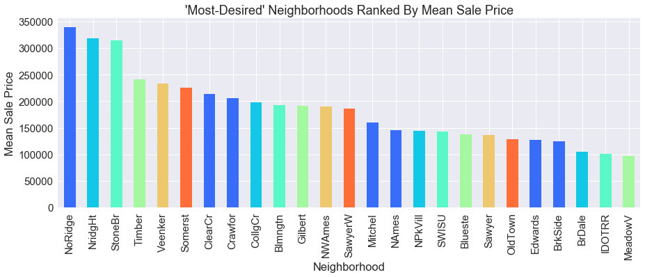

```python
neighborhoodMeans = (training_data['SalePrice']
           .groupby(training_data['Neighborhood'])
           .mean()
           .sort_values(ascending=False))

plt.figure(figsize=(15,5))
neighborhoodMeans.plot.bar(color=sns.color_palette('rainbow'))
plt.ylabel("Mean Sale Price")
plt.title("\'Most-Desired\' Neighborhoods Ranked By Mean Sale Price")
plt.show()
```

#### Heatmap of standard deviation of the houses prices sold by neighborhood

Plot a heatmap of the standard deviation for house prices sold by neighborhood.  
This shows the heterogeneity of the house prices in each neighborhood.

```python
# Compute the mean of houses prices by neighborhood
stdPriceHeatMap = (
    training_data[["Neighborhood", "SalePrice"]]
        .groupby("Neighborhood")
        .agg("std")
).reset_index()

# Add latitude and longitude
stdPriceHeatMap["latitude"] = stdPriceHeatMap.apply(lambda x: get_latitude(x.Neighborhood) , axis=1)
stdPriceHeatMap["longitude"] = stdPriceHeatMap.apply(lambda x: get_longitude(x.Neighborhood), axis=1)

# Remove the not found locations
stdPriceHeatMap = stdPriceHeatMap[stdPriceHeatMap.latitude != 0]

# Change the name of the counter
stdPriceHeatMap.columns = [{"SalePrice": "PriceStd"}.get(col, col) for col in stdPriceHeatMap.columns]

# Have a look at the results
print(stdPriceHeatMap[:5])
```

```
  Neighborhood      PriceStd   latitude  longitude
0      Blmngtn  28877.833382  42.056373 -93.644666
1      Blueste  19091.883092  42.023090 -93.663783
2       BrDale  12805.216148  42.033715 -93.611455
3      BrkSide  41553.653570  42.028950 -93.629748
4      ClearCr  51125.759088  42.030781 -93.631913
```

```
fig = gmaps.figure()
heatmap_layer = gmaps.heatmap_layer(
    stdPriceHeatMap[['latitude', 'longitude']],
    weights=stdPriceHeatMap['PriceStd'],
    max_intensity=stdPriceHeatMap.SalePrice.max(),
    point_radius=30.0
)
fig.add_layer(heatmap_layer)
fig
```

[figure not shown]

Here we can see the standard deviation of houses prices which indicates how far the prices are spread out from the mean. In the north of Ames the standard deviation is really high which means that the prices are really spread out and thus heterogeneous. Then we can assume that there is less information about the exact price in the "Neighborhood" parameter when the standard deviation of prices within this neighborhood is high.

Furthermore, having a look at the distribution is important as we can spot outliers and think about removing them (or not) later.

#### Prices distribution kde plot

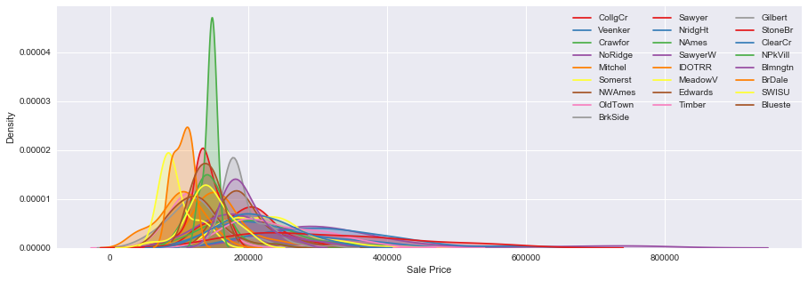

```python
sns.set(palette=sns.color_palette("Set1", n_colors=40, desat=1))

plt.figure(figsize=(15, 5))

for loc in locations:
    sns.kdeplot(
        training_data[training_data.Neighborhood == loc].SalePrice.rename(loc),
        shade=True
    )

plt.legend(ncol=3)
plt.xlabel("Sale Price")
plt.ylabel("Density")
plt.show()
```

Have a deeper look at price inequalities. Inspect the quarters that have a significant gap between them.

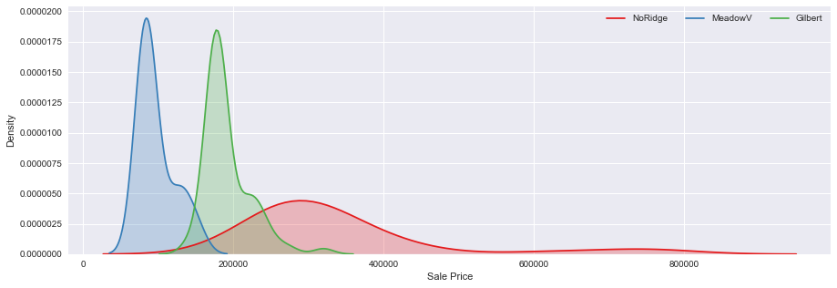

```python
selected_locations = ["NoRidge", "MeadowV", "Gilbert"]

plt.figure(figsize=(15, 5))

for loc in selected_locations:
    sns.kdeplot(
        training_data[training_data.Neighborhood == loc].SalePrice.rename(loc),
        shade=True
    )

plt.legend(ncol=3)
plt.xlabel("Sale Price")
plt.ylabel("Density")
plt.show()
```

Here we have a closer look at the KDE for three neighborhoods. We can see two distributions are similar but one neigborhood has higher prices. And the neighborhood `NoRidge` has a low density and really high prices.

#### Heatmap of mean house prices for three neighborhoods

Now we look at the heatmap of the mean for these three neighborhood.

```
selected_meanPriceHeatMap = \
    meanPriceHeatMap.set_index("Neighborhood").loc[selected_locations]

fig = gmaps.figure()
heatmap_layer = gmaps.heatmap_layer(
    selected_meanPriceHeatMap[['latitude', 'longitude']],
    weights=selected_meanPriceHeatMap['SalePrice'],
    max_intensity=selected_meanPriceHeatMap.SalePrice.max(),
    point_radius=30.0
)
fig.add_layer(heatmap_layer)
fig
```

[figure not shown]

As we could imagine, those two districts are far from each other and the social inequalities are expected to be high. Houses/Apartments in `NoRidge` are located in the downtown wereas the `MeadowV` district is appart from the city.

#### Inequalities visualization

Let's describe those inequalities, digging more into the details:

```python
categories_agg = {
    # Overall quality of the houses aggregated by mean
    "OverallQual":  "mean",

    # Proportion of the district that has Central air cond.
    "CentralAir":   lambda x: np.mean(x=="Y"),

    # Mean area of the houses in a given neighborhood
    "GrLivArea":    "mean",

    # Mean area of lot sizes
    "LotArea":      "mean",

    # Proportion of the district that has at least
    # a good looking house
    "ExterQual":    lambda x: np.mean(x.isin(["Ex", "Gd"])),

    # Mean area of pools (no pool = 0)
    "PoolArea":     lambda x: np.mean(x.fillna(0)),
}

categories = list(categories_agg)

inequalities_df = (training_data

      # Keep only the selected locations
    [training_data.Neighborhood.isin(selected_locations)]

      # Get only a few subset of relevant data
    [["Neighborhood"]+categories]

      # Group and aggregate
    .groupby("Neighborhood")

      # Aggregate functions
    .agg(categories_agg)

      # Drop other neighborhoods
     .dropna()

      # Normalize in order to spider plot
     .apply(lambda x: x/x.max())
)
```

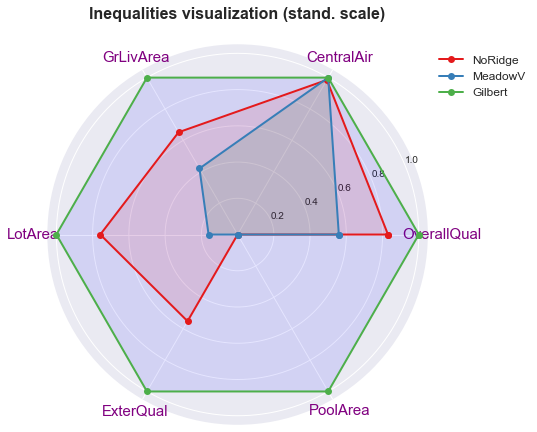

```python
from itertools import cycle
colors = cycle(["r", "g", "b"])

# Preprocess data to plot
values = np.hstack((inequalities_df.values, inequalities_df.values[:,[0]])).T
angles = [n / float(len(categories)) * 2 * np.pi for n in range(len(categories))]
angles += angles[:1]

# Then plot the data
plt.figure(figsize=(7, 7))

ax = plt.subplot(111, polar=True)
ax.plot(angles, values, "-o",linewidth=2, linestyle='solid')
ax.legend(selected_locations, prop={'size':12}, bbox_to_anchor=(1, 1))
for v in values.T:
    ax.fill(angles, v, color=next(colors), alpha=.1)

plt.xticks(angles[:-1], categories, color='purple', size=15)
plt.title("Inequalities visualization (stand. scale)", size=16, weight="bold")
plt.show()
```

- The overall quality of the houses aggregated by mean;
- The proportion of the district that has central air conditionning;
- The mean area of the houses in a given neighborhood;
- The mean area of lot sizes;
- The proportion of the district that has at least a good looking house;
- The mean area of pools.

#### Conclusion on spacial differentiation

The first thing that comes to mind when dealing with housing is probably *where ?* and you'll be probably right if you say that one of the main criteria in the price setting of a house or an appartment is its location. This is especialy true is the USA as shown in the following heatmap ([Source](https://www.trulia.com/home_prices/California/San_Francisco-heat_map/)) of San Francisco median home prices. The price range is huge (a log scale would almost be needed ...).

[figure not shown]

Multiple factors are leading to this analysis, including differents standards of living with regard to the districts (house/appartment/villa, area, build quality). Those criterias cumulate in order to estimate the overall price of the house, thus the neighborhood has no value by itself determining the price of houses, but it underlies several factors (including ones that the dataset may lack of).

All of this leads us to distinguish spatially the analysis when dealing with housing. (for instance for the outliers analysis, for filling the Na values in the test set, and much more). The important point is that **there are underlying latent factors in the spatial information** and those are very important in the price setting as shown in the next part.

**Funny fact:** please note that even in the less valuated neighborhoods, homes have as much access to air conditionning as much more valuated ones. Welcome in America!

### Determine the relationship between numerical features

We chose here to process the categorical data later and at first to analyse the numerical features in order to have a better understanding of the dataset.  
We will see later that the non numerical data will be transformed to numerical data using `dummy variables` and that the indicator that we use in this section will also apply to those dummy variables, but the results are much less human-readable.

Please note that the years can be considered as numerical data or as categorical data for regression. We will see later which is the best for each year (as for categorical year data, the best would be to create 5 to 10 years periods instead of multitudes of years).

```python
# Use numerical data at first
num_data = training_data._get_numeric_data().dropna()

# False numerical data (int or float that shoult be categorical)
num_data.drop(columns=[
    "MSSubClass",
    #"YearBuilt",    # Can be discussed
    #"YearRemodAdd", # Can be discussed
    #"GarageYrBlt",  # Can be discussed
    #"GarageYrSold", # Can be discussed
    "MoSold",
], inplace=True)
```

#### Display correlation coefficients

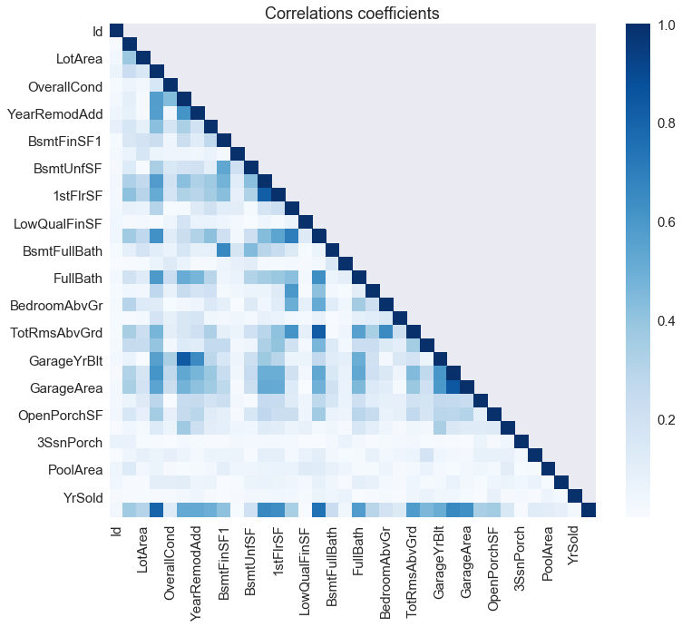

```python
sns.set(palette=sns.color_palette("Blues"), font_scale=1.5)

# Getting the correlation coefficients from numerical data
corr_num_data = num_data.corr().abs()

mask = np.zeros_like(corr_num_data)
mask[np.triu_indices_from(mask, 1)] = True

plt.figure(figsize=(12, 10))
plt.title("Correlations coefficients")
sns.heatmap(corr_num_data, mask=mask, cmap="Blues")
plt.show()
```

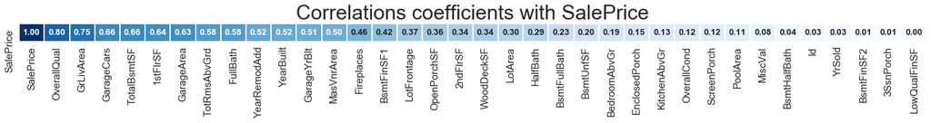

```python
sorted_corr = (corr_num_data
    # Select the SalePrice line in the correlation tab
    .loc[:, ["SalePrice"]]
    # Sort values by descending correlation coef with SalePrice
    .sort_values(by="SalePrice", ascending=False).T
)

# Plot the heatmap
plt.figure(figsize=(24, .5))
ax = sns.heatmap(sorted_corr,
                 # Annotations options
                 annot=True, annot_kws={"size":13, "weight":"bold"}, fmt=".2f",
                 # Display options
                 linewidths=1, cbar=False, cmap="Blues")

# Resize the labels
for label in ax.get_xticklabels()+ax.get_yticklabels():
    label.set_fontsize(15)

plt.title("Correlations coefficients with SalePrice")
ax.title.set_fontsize(30)

plt.show()
```

Looking at the sales price correlation heatmap, we can spot which features are the most relevant to select them for our prediction model. And as we can see there are features that don't influence *a regression based model* the price such as `LowQualFinSF: Low quality finished square feet (all floors)`. Indeed what is shown that matters most is the `OverallQual: Overall material and finish quality` which makes sense. Imagine you want to buy a house the overall quality will more matter to you than the "quality finished square feet".

What matters also is `GrLivArea: Above grade (ground) living area square feet` and `GarageCars: Size of garage in car capacity`. It seems that features related to garages are more important. Which makes sense for this kind of not-super-big town.

#### Mutual information

The mutual information measures the amount of information that is contained in each couple of variables. In that specific case it it very interesting to estimate the mutual information shared with the SalePrice parameter.

This is also more relevant than looking at the correlation which doesn't care of the linearity of the association of two variables whereas the correlation does. But the mutual information is also more difficult to calculate as we must have an idea of the the distribution of the variables. This is what is performed by scikit-learn that works with samples and calculates the MI from the cardinality of the generated sets.

$\begin{align} MI(U, V) &= E\left( ln\frac{p(u, v)}{p(u)p(v)} \right)\\ &= \sum_{i=1}^{|U|} \sum_{j=1}^{|V|} \frac{|U_i \cap V_j|}{N} \cdot log \left(\frac {N \cdot |U_i \cap V_j|} {|U_i| \cdot |V_j|} \right) \text{ (Using Sklearn sampling cardinality)} \end{align}$

**Normalized MI:**

$ NMI(U, V) = \frac {MI(U, V)} {\sqrt{|U| \cdot |V|}} $

```python
from sklearn.metrics import normalized_mutual_info_score

def calc_MI(x, y):
    mi = normalized_mutual_info_score(x, y)
    return mi
```

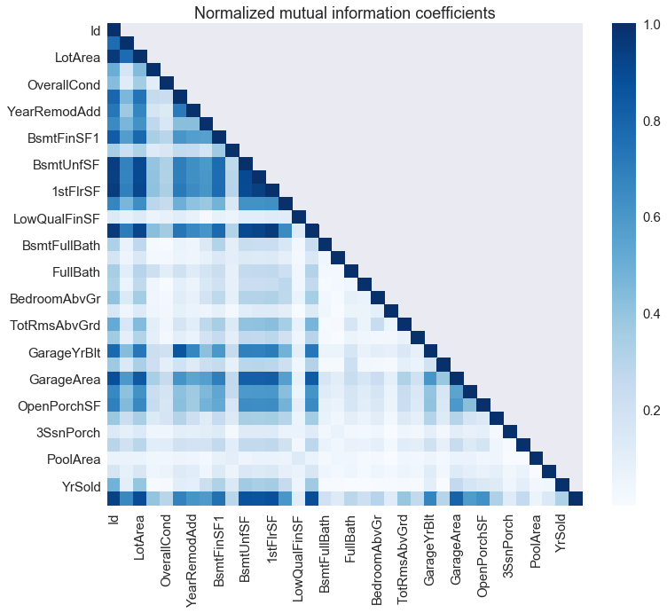

```python
cols = num_data.columns

mutual_num_data = pd.DataFrame(
    [[ calc_MI(num_data[i], num_data[j])
          for j in cols ] for i in cols],
    index=cols,
    columns=cols
)

plt.figure(figsize=(12, 10))
plt.title("Normalized mutual information coefficients")
sns.heatmap(mutual_num_data, mask=mask, cmap="Blues")
plt.show()
```

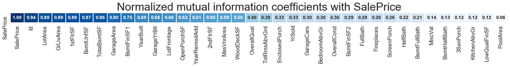

```python
sorted_mutual = (mutual_num_data
    # Select the SalePrice line in the mutual information tab
    .loc[:, ["SalePrice"]]
    # Sort values by descending mutual information coef with SalePrice
    .sort_values(by="SalePrice", ascending=False).T
)

# Plot the heatmap
plt.figure(figsize=(24, .5))
ax = sns.heatmap(sorted_mutual,
                 # Annotations options
                 annot=True, annot_kws={"size":13, "weight":"bold"}, fmt=".2f",
                 # Display options
                 linewidths=1, cbar=False, cmap="Blues")

# Resize the labels
for label in ax.get_xticklabels()+ax.get_yticklabels():
    label.set_fontsize(15)

plt.title("Normalized mutual information coefficients with SalePrice")
ax.title.set_fontsize(30)

plt.show()
```

As expected, the Id of the sale is the indicator that contains the more information about the price. As it is a primary key for the price this is obvious, but it has no phyisical meaning and is not a feature of the data. Therefore we have to eliminate it. Thought, this draw the attention on the fact that mutual information doesn't search for linear correlation (for which the Id is not so much correlated to the price).

The most relevant features are therefore the ones that comes to mind when buying a house, namely those related to the surface and the spacial information (district).

#### Have a look at the most relevant distributions

```python
sns.set(style="white", color_codes=True)
plot_params = dict(x=num_data["SalePrice"],
                   kind='kde', color="skyblue",
                   shade=True, shade_lowest=False)
def jointplot_num_df(y_name, plot_params=plot_params):
    sns.jointplot(y=num_data[y_name], **plot_params)
    plt.title(y_name)
    plt.show()
```

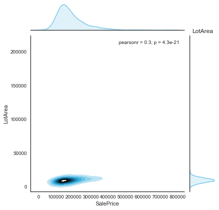

```python
jointplot_num_df("LotArea")
```

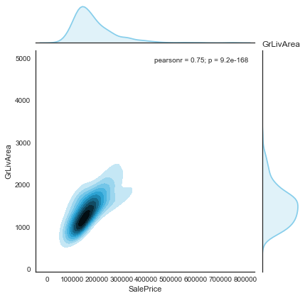

```python
jointplot_num_df("GrLivArea")
```

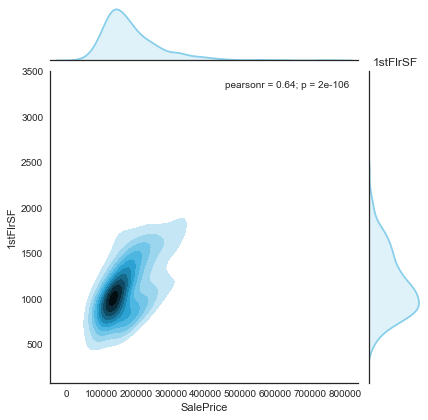

```python
jointplot_num_df("1stFlrSF")
```

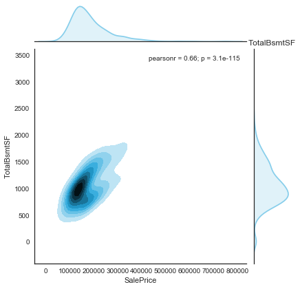

```python
jointplot_num_df("TotalBsmtSF")
```

These heatmaps plotted along the distributions help us to understand the reliable part of the heatmap (the background has been removed for clarity). The darker areas in the graph indicates a huge concentration of data points and therefore a huge confidence in predicting prices using those areas as training.

The distributions all seems to be gaussian or at least could be approximated by a gaussian. They therefore include outliers. In the following section, we will process the data, in order to have realiable data that we can use to train a model.

## Preprocessing

First, set the Id as index to not infer from the id.

```python
training_data.set_index("Id", inplace=True)
```

**Note on preprocessing**

Preprocessing data is a key factor for having good predictions. In the real world, data is always noisy, there are missing values, not coherent values, and so forth.  
However, it is not good to remove all the data that seems to be far from what we expect to infer. By removing outliers for instance, we get rid of a lot of very important information that is located nowhere else. For instance if there were houses with a heliport, there would be only a very few, and they would be very expensive. Based on the price criteria, it would probably be considered as an outlier, losing all the information about the added value (and latent factors) of a heliport.  
One way to decrease the impact of outliers removal in our case is to remove them by neighborhood as we saw before that the spacial factor is a very discriminent one.

**Strategy brief**

The important question for scoring is how much is that worth to decrease the accuracy of the very few specific data, in order to increase the accuracy for the homogeneous data.  
For instance, if we remove the outliers, that will affect the highest priced houses price prediction. but that will also make improvements to the prediction on the average house price prediction.  
The point is probably to pay attention to the scoring mecanism. As seen later in this notebook, here the scoring mechanism doesn't penalize more the error on more expensive houses than cheaper ones. Then it may be a good strategy to predict very well on the average house and have a less accurate prediction (taking the risk of losing information)on the others. Though this is also what would happen in real-life, the most expensive houses are given to specialized real-estates and not to the local one, aren't they ?

### Outliers removal

Here we chose to work district by district as it happens in real life, when real estates are evaluating a house, the neighborhood is probably one of the best criteria and the price setting is made according to the previous prices set in the same area for equivalent houses (one fact about district is that in the same area, chances are very high that the houses have the same characteristics, especialy in the US).

Thus, we chose to remove the outlier prices in each neighborhood. In all the nieghborhoods we have seen that the prices distribution is gaussian and therefore removing the outliers makes sense.

#### Outliers with Box-and-Whisker Plot

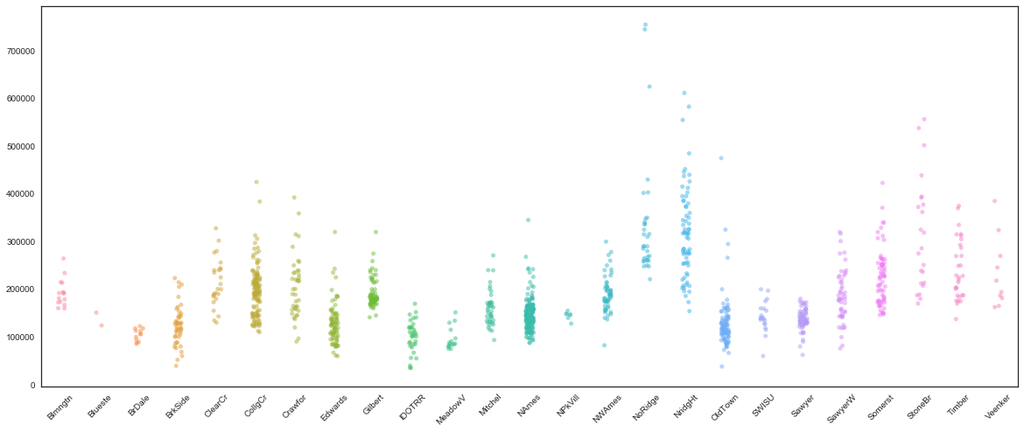

```python
plt.figure(figsize=(20, 8))
sns.stripplot(x = training_data.Neighborhood.values,
              y = training_data.SalePrice.values,
              order = np.sort(training_data.Neighborhood.unique()),
              jitter=0.1, alpha=0.5)

plt.xticks(rotation=45)
plt.show()
```

Here we can see again how spread out the sales price can be according to neighborhood and guess the huge amount of outliers.

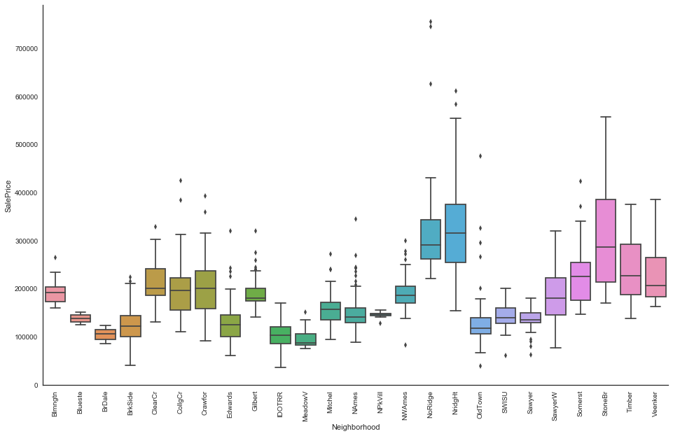

```python
fig, ax = plt.subplots(figsize=(16,10))

sns.despine(left=False)

sns.boxplot("Neighborhood","SalePrice",data=training_data, ax=ax)

for ax in fig.axes:
    plt.sca(ax)
    plt.xticks(rotation=90)

plt.show()
```

With those boxplot we can see clearly the outliers. For the majority of the features there are a lot of outliers. Thus it will be interested to remove them. Which we will do later.

```python
cumulative_values = (training_data[["Neighborhood", "SalePrice"]]
    .groupby("Neighborhood")
    .agg({"SalePrice":
              {"3% price": lambda x: np.percentile(x, 3),
               "97% price": lambda x: np.percentile(x, 97)}
    }))

# Print values of interest
cumulative_values.loc[selected_locations]
```

| Neighborhood | SalePrice 3% price | SalePrice 97% price |
| --- | --- | --- |
| NoRidge | 246110.0 | 745700.0 |
| MeadowV | 75210.0 | 144092.0 |
| Gilbert | 159700.0 | 259314.5 |

```python
def is_not_outlier(row):
    return (
        row.SalePrice >= cumulative_values.loc[row.Neighborhood][("SalePrice", "3% price")]
        and
        row.SalePrice <= cumulative_values.loc[row.Neighborhood][("SalePrice", "97% price")]
    )

training_data = training_data[training_data.apply(is_not_outlier, axis=1)]

print("There are {} rows and {} columns in the training dataset once the outliers removed."
          .format(*training_data.shape))
```

```
There are 1104 rows and 80 columns in the training dataset once the outliers removed.
```

### Use categorical data for regression : introducing Dummy Variables

Categorical data can't be use as is for regression and therefore we have into transform them to numerical data. One way to perform that is used to do that is dummy variables. The principle is quite simple: for a categorical type that includes n elements $\{e_1, ..., e_n \}$, we need $n-1$ dummy variable to represent a type (in the space $\{0, 1\}^{n-1}$). The projection from from the categorical space $C$ to the numerical space is computed as follows:

$$ \begin{align} f : \hspace{1cm} e_1 &\longrightarrow (\delta_{(1, 1)}, \dots, \delta_{(1, n-1)})\\ \dots \\ e_i &\longrightarrow (\delta_{(i, 1)}, \dots, \delta_{(i, i)}, \dots, \delta_{(i, n-1)})\\ \dots \\ e_{n-1} &\longrightarrow (\delta_{(n-1, 1)}, \dots, \delta_{(n-1, n-1)})\\ e_{n} &\longrightarrow (\delta_{(n, 1)}, \dots, \delta_{(n, n-1)}) \hspace{1cm} \text{(which is null)}\\ \end{align} $$ where $\delta{(i, j)}$ is the kronecker symbol.

```python
from pandas.api.types import CategoricalDtype

# Get the numerical columns
num_data = training_data._get_numeric_data().dropna()
numerical_cols = num_data.columns

# Isolate categorical data
categorical_cols = list(training_data.dtypes == 'category')
categorical_data = training_data.iloc[:,categorical_cols]

print("Categorical data columns:\n")
print(", ".join(categorical_data.columns))
```

```
Categorical data columns:

MSZoning, Street, Alley, LotShape, LandContour, Utilities, LotConfig, LandSlope, Neighborhood, Condition1, Condition2, BldgType, HouseStyle, RoofStyle, RoofMatl, Exterior1st, Exterior2nd, MasVnrType, ExterQual, ExterCond, Foundation, BsmtQual, BsmtCond, BsmtExposure, BsmtFinType1, BsmtFinType2, Heat…
```

```python
dummies = [pd.get_dummies(categorical_data[col_name], prefix=col_name)
           for col_name
           in categorical_data.columns]
```

```python
pure_numerical_data = training_data._get_numeric_data()
numerical_dummy_data = pd.concat([pure_numerical_data]+dummies, axis=1)
```

```python
print("There are {} rows and {} columns in the dataframe including dummies variables."
          .format(*numerical_dummy_data.shape))
```

```
There are 1104 rows and 280 columns in the dataframe including dummies variables.
```

### Categorical-numerical analysis

As seen before this is not clear that a certain number of features are catogorical or not (among them the year columns). This section is aiming to determine whether or not each of those features is numerical.

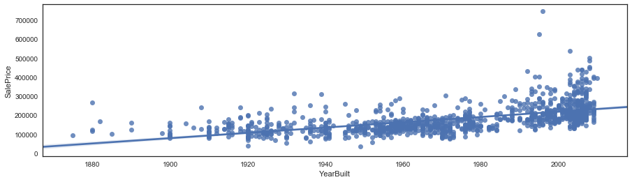

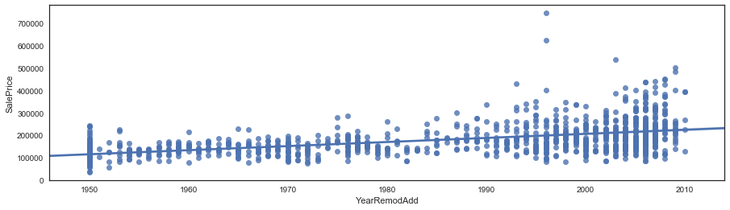

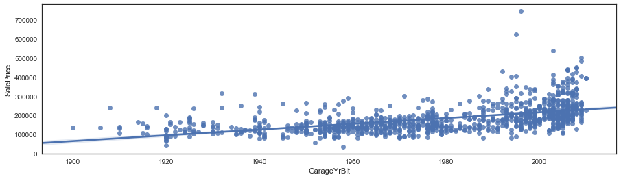

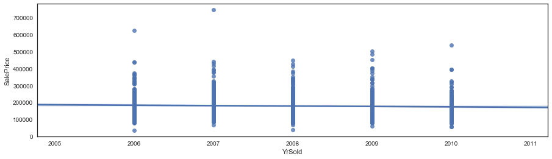

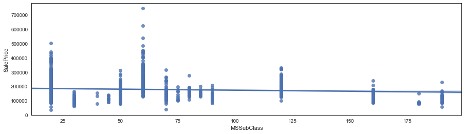

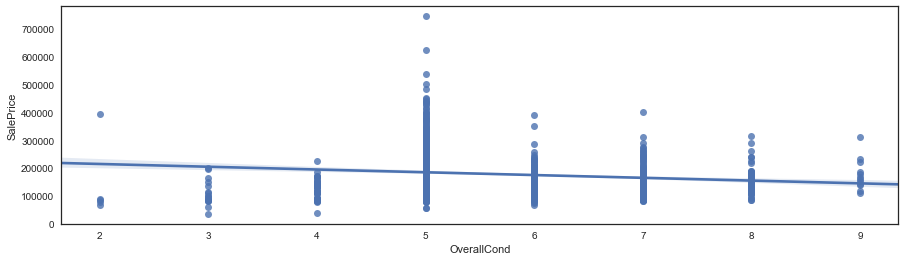

```python
ambiguous_features = [
    "YearBuilt",
    "YearRemodAdd",
    "GarageYrBlt",
    "YrSold",
    "MSSubClass",
    "OverallCond"
]

for feat_name in ambiguous_features:
    plt.figure(figsize=(15,4))
    sns.regplot(training_data[feat_name], training_data.SalePrice)
    plt.show()
```

- `YearBuilt` Can be considered as a numerical regression variable as the regression is monotonic and there are plenty of different values, which are well distributed on the date range.
- `YearRemodAdd` and `GarageYrBlt` can be considered as numerical data or taken as categorical data by extraction periods. With regard to the regression plots, we chose to keep them numerical.
- `YrSold` Has only a few distinct values (5) and a regression towards the price setting of a house cannot take advantage of this parameter as a numerical parameter (cf the plot) therefore it has to be used as a categorical data.
- `MSSubClass`, `OverallCond` These data have to be considered as categorical.

```python
# Extra columns to convert
extra_categorical = ["YrSold", "MSSubClass", "OverallCond"]

# Convert types
for col_name in extra_categorical:
    training_data[col_name] = training_data[col_name].astype("category")

# Then convert those columns to dummy variables features
dummies = [pd.get_dummies(training_data[col_name], prefix=col_name)
           for col_name
           in extra_categorical]
pd.concat([numerical_dummy_data]+dummies, axis=1)

# Finaly drop the old numerical features
numerical_dummy_data.drop(columns=extra_categorical, inplace=True)

# Removing those columns from the numerical ones
numerical_cols = set(numerical_cols)-set(extra_categorical)
```

```python
print("There are {} rows and {} columns in the dataframe including dummies variables."
          .format(*numerical_dummy_data.shape))
```

```
There are 1104 rows and 277 columns in the dataframe including dummies variables.
```

### Drop unrelevant data

```python
numerical_data = numerical_dummy_data.dropna()

print("There are {} rows and {} columns in the droped NA dataframe."
          .format(*numerical_data.shape))

preprocessed_data_X = numerical_data.drop(columns=["SalePrice"])
preprocessed_data_Y = numerical_data[["SalePrice"]]
```

```
There are 851 rows and 277 columns in the droped NA dataframe.
```

### Normalization/Standardization

#### Why normalizing/standardizing?

The process of normalization/standardization is usefull when value ranges of different features are very different. This avoids for the training algorithm to overweight a priori some features (the ones that have the greatest values). It is therefore very important to normalize/standardize each of the features for the estimator not to be biaised.

#### Normalization vs Standardization

Normalization rescales the values into a range of $\left[0,1\right]$. This doesn't preserve the characteristics of gaussian distributions are the outliers are lost. But this have the advantage of having positive values only. $$X_{normalized}=\frac{X−X_{min}}{X_{max}−X_{min}}$$

Standardization rescales data to have a mean ($\mu$) of 0 and standard deviation ($\sigma$) of 1. It preserves the gaussian characteristics of the model and not all the values are positive. $$X_{standardized}=\frac{X−\mu}{\sigma}$$

In our specific case, as we deal with gaussian processes (we have seen that the prices follows a Gauss function with respect of almost every important factor). Furthermore, when using test data, the scaler has alrady been computed on the training data, and using a normalization would include a risk of having values greater that one (if the max of a feature in the test data is greater than the max for this feature in the training data).

Therefore we chose to **standardize** our data.

#### Standardization Process

```python
from sklearn.preprocessing import StandardScaler

scalerX = StandardScaler().fit(preprocessed_data_X)
scalerY = StandardScaler().fit(preprocessed_data_Y)

def inverse_y(y):
    """
        Denormalize according to the y variable
    """
    return np.float32(scalerY.inverse_transform(y, copy=True))

# All the dataset including the dummy variables
standard_X = pd.DataFrame(
    scalerX.transform(preprocessed_data_X),
    columns=preprocessed_data_X.columns
)
standard_Y = pd.DataFrame(
    scalerY.transform(preprocessed_data_Y),
    columns=preprocessed_data_Y.columns
)

standard_X.describe()
```

|  | LotFrontage | LotArea | OverallQual | YearBuilt | YearRemodAdd | MasVnrArea | BsmtFinSF1 | BsmtFinSF2 | BsmtUnfSF | TotalBsmtSF | ... | SaleType_ConLw | SaleType_New | SaleType_Oth | SaleType_WD | SaleCondition_Abnorml | SaleCondition_AdjLand | SaleCondition_Alloca | SaleCondition_Family | SaleCondition_Normal | SaleCondition_Partial |
| --- | --- | --- | --- | --- | --- | --- | --- | --- | --- | --- | --- | --- | --- | --- | --- | --- | --- | --- | --- | --- | --- |
| count | 8.510000e+02 | 8.510000e+02 | 8.510000e+02 | 8.510000e+02 | 8.510000e+02 | 8.510000e+02 | 8.510000e+02 | 8.510000e+02 | 8.510000e+02 | 8.510000e+02 | ... | 8.510000e+02 | 851.000000 | 851.0 | 8.510000e+02 | 8.510000e+02 | 851.000000 | 8.510000e+02 | 8.510000e+02 | 8.510000e+02 | 8.510000e+02 |
| mean | -2.442230e-16 | 7.201447e-17 | -3.172811e-16 | -2.865967e-15 | 4.133004e-15 | 7.514553e-17 | 7.097078e-17 | 6.262128e-18 | 2.087376e-18 | 5.218440e-17 | ... | 1.043688e-17 | 0.000000 | 0.0 | -1.168930e-16 | 4.070383e-17 | 0.000000 | -3.131064e-17 | -3.548539e-17 | -1.294173e-16 | 5.844652e-17 |
| std | 1.000588e+00 | 1.000588e+00 | 1.000588e+00 | 1.000588e+00 | 1.000588e+00 | 1.000588e+00 | 1.000588e+00 | 1.000588e+00 | 1.000588e+00 | 1.000588e+00 | ... | 1.000588e+00 | 1.000588 | 0.0 | 1.000588e+00 | 1.000588e+00 | 1.000588 | 1.000588e+00 | 1.000588e+00 | 1.000588e+00 | 1.000588e+00 |
| min | -2.325792e+00 | -1.652114e+00 | -3.119909e+00 | -3.007479e+00 | -1.699858e+00 | -5.791177e-01 | -9.947673e-01 | -2.693773e-01 | -1.335252e+00 | -2.656905e+00 | ... | -6.872081e-02 | -0.333116 | 0.0 | -2.387632e+00 | -2.551105e-01 | -0.034300 | -9.741620e-02 | -1.293306e-01 | -2.054473e+00 | -3.396089e-01 |
| 25% | -4.788150e-01 | -4.411607e-01 | -8.912779e-01 | -6.318814e-01 | -9.366430e-01 | -5.791177e-01 | -9.947673e-01 | -2.693773e-01 | -7.313691e-01 | -6.430217e-01 | ... | -6.872081e-02 | -0.333116 | 0.0 | 4.188250e-01 | -2.551105e-01 | -0.034300 | -9.741620e-02 | -1.293306e-01 | 4.867429e-01 | -3.396089e-01 |
| 50% | -5.231126e-03 | -1.009543e-01 | -1.484008e-01 | 8.405201e-02 | 4.466851e-01 | -5.791177e-01 | -1.179166e-01 | -2.693773e-01 | -2.035309e-01 | -1.080644e-01 | ... | -6.872081e-02 | -0.333116 | 0.0 | 4.188250e-01 | -2.551105e-01 | -0.034300 | -9.741620e-02 | -1.293306e-01 | 4.867429e-01 | -3.396089e-01 |
| 75% | 4.683527e-01 | 2.923755e-01 | 5.944763e-01 | 9.952400e-01 | 8.759938e-01 | 3.381325e-01 | 6.100787e-01 | -2.693773e-01 | 5.367847e-01 | 6.164349e-01 | ... | -6.872081e-02 | -0.333116 | 0.0 | 4.188250e-01 | -2.551105e-01 | -0.034300 | -9.741620e-02 | -1.293306e-01 | 4.867429e-01 | -3.396089e-01 |
| max | 5.298908e+00 | 1.205586e+01 | 2.823108e+00 | 1.223037e+00 | 1.162200e+00 | 7.759521e+00 | 4.261685e+00 | 9.502730e+00 | 3.889452e+00 | 5.338774e+00 | ... | 1.455163e+01 | 3.001960 | 0.0 | 4.188250e-01 | 3.919870e+00 | 29.154759 | 1.026523e+01 | 7.732122e+00 | 4.867429e-01 | 2.944564e+00 |

8 rows × 276 columns

## Metrics

**Note on the metrics**

As the data is standardized the Mean Absolute error and the Mean Square error are computed on the standardized data dans therefore with respect to the variance and the mean of the dataset. As a reminder, the scaling of the y data is computed as follows: $y_{standard} = \frac{y - mean(y)}{std(y)}$.

The metric that is suggested is the folloving one:

$$ \begin{align} error_{RMSE(log)}(\hat{y}, y) &= \sqrt{\sum_i \left[log\left(\hat{y}_i\right) - log\left(y_i\right)\right]^2}\\ &= \sqrt{\sum_i \left[log\left(\frac{\hat{y}_i}{y_i}\right)\right]^2} \end{align} $$

Therefore, by dimensionality,

$$ \begin{align} dim \left[\frac{\hat{y}}{y}\right] &= dim \left[exp\left(error_{RMSE(log)}\left(\hat{y}, y\right)\right)\right] \end{align} $$

Then to have an approcimation of the error rate on each house price:

$$ \begin{align} error_{rate}\left(\hat{y}, y\right) &= \left[e^{error_{RMSE(log)}\left(\hat{y}, y\right)}\right] - 1\\ &= exp\left(\sqrt{\sum_i \left[log\left(\frac{\hat{y}_i}{y_i}\right)\right]^2}\right) - 1 \end{align} $$

For instance, an error of 0.0150 with this metric, would correspond to a precision of $exp(0.015) - 1 = 1,51\%$ on the estimated price.

This led us to create a fourth metric which will be computed as the error rate above, based on the RMSE(log). We call it *Precision* in this document.

```python
from sklearn.metrics import get_scorer, make_scorer

def MeanAbsErr(*args, **kwargs):
    """
        Returns the average absolute error.
        Note that the inputs have to be standardized!
        The arguments are the seame as for sklearn 'neg_mean_absolute_error'
    """
    NegMeanAbsoluteError = get_scorer('neg_mean_absolute_error')
    return -NegMeanAbsoluteError(*args, **kwargs)

def MeanSqrErr(*args, **kwargs):
    """
        Returns the average square error.
        Note that the inputs have to be standardized!
        The arguments are the seame as for sklearn 'neg_mean_squared_error'
    """
    NegMeanSquareError = get_scorer("neg_mean_squared_error")
    return -NegMeanSquareError(*args, **kwargs)

def logRMSE_score(y_true, y_pred, *args):
    """
        Returns the RMSE between the logarithm of the predicted value
        and the logarithm of the observed sales price.

        Note that this metric destandardized the price
    """
    return np.sqrt(np.mean(
        # Please note that the minus operator is more accurate in python
        # than the division operator when dealing with float
        np.log(inverse_y(y_pred))
        -
        np.log(inverse_y(y_true))
    )**2)

def precision_score(y_true, y_pred, *args):
    """
        Returns the precision score as described above.
        Returns a percentage

        Note that this metric denormalize the price
    """
    return 100*(np.exp(logRMSE_score(y_true, y_pred, *args))-1)

# Convert custom score functions to sklearn scorers
logRMSE = make_scorer(logRMSE_score)
precision = make_scorer(precision_score)
```

```python
metrics_list = [{"name":"Mean Absolute Error (Standard)",  "function":MeanAbsErr},
                {"name":"Mean Square Error (Standard)",    "function":MeanSqrErr},
                {"name":"RMSE (log)",                      "function":logRMSE},
                {"name":"Precision (%)",                   "function":precision},]
```

## Price prediction

### Test function

**Note on shuffling for cross-validation**  
`KFold` cross-validation method splits the data into $n$ chunks and then performs the training on $n-1$ folds and the validation on the remaining fold, $n$ times. This draw the importance on having homogeneous data inside each chunk, else the training and/or validation could be biaised on at least a subset of the tests.  
This homogeneity can be measured by the standard deviation of the accuracies obtained through the tests.

```python
from sklearn.cross_validation import KFold, cross_val_score
from itertools import product as cart_product


def predict_and_test_cv(
    # training data
    X, Y,
    # estimation functions (see sklearn doc)
    estimators_list,
    # metric functions
    metrics_list,
    # number of folds used in k-fold cross-validation
    folds_nb=5):

    """
        This function trains predict and validate the model,
        returning the accuracy for multiple models and metrics.

        Input data structures:
        - estimators_list: [{"name":name estimator 1", "function":estimator_function_1},
                            {...},
                            ...]
        - metrics_list: [{"name""name metric 1", "function":metric_function_1},
                         {...},
                         ...]

        Uses cross validation as validation method
    """

    def predict_and_score_one(row):
        """
            To apply on results dataframe
        """
        return np.mean(cross_val_score(
            row.Estimator["function"],
            X, Y,
            cv=cv,
            scoring=row.Metric["function"]
        ))

    # Use cross validation to avoid overfitting
    # The shuffle is directly performed by the KFold function
    cv = KFold(X.shape[0], folds_nb, shuffle=True, random_state=33)

    params = pd.DataFrame(
        list(cart_product(estimators_list, metrics_list)),
        columns=["Estimator", "Metric"]
    )

    params["Score"] = params.apply(predict_and_score_one, axis=1)
    params[["Estimator", "Metric"]] = \
        params[["Estimator", "Metric"]].applymap(lambda x: x["name"])
    params.set_index(["Estimator", "Metric"], inplace=True)
    return pd.DataFrame(params)
```

[output not shown]

```python
def predict_and_plot_cv(*args, **kwargs):
    """
        Same args as for predict_and_test
    """
    prediction_result = predict_and_test_cv(*args, **kwargs)\
        .reset_index()\
        .pivot("Estimator", "Metric", "Score")

    # Plot the result
    axs = prediction_result\
        .plot.bar(subplots=True, figsize=(15, 5), layout=(1, 4))
    plt.suptitle("Errors (Standardized cross-validation data)")
    for ax in axs.reshape(-1):
        ax.legend(fancybox=True, shadow=True)
    plt.show()

    # Return the prediction results
    return prediction_result
```

### Prediction

Even before starting the prediction, we know that the tree-based approach (Decision Tree, Random forest) will perform way better as there might be remaining categorical data hidden in the numerical data (for instance MSSubClass if we forgot to parse it). There can also be variables that are not monotonic which is a problem when performing a regression.

And also, dummy variables are more efficient when dealing with random forests (in the case of traditionnal regression, it adds so many weights that is becomes computationnaly very expensive to train well.

#### Estimators

```python
from sklearn.linear_model import SGDRegressor, MultiTaskElasticNet
from sklearn.svm import SVR
from sklearn.ensemble import ExtraTreesRegressor

# First, use stochastic Gradient descent
SGDestimator = SGDRegressor(loss='squared_loss', penalty='l2',  random_state=33)

# Use a random forest (uses one job per logical CPU core on I7-7700HQ)
ETRestimator = ExtraTreesRegressor(n_estimators=10,random_state=33,n_jobs=8)

# Then try SVM regression with kernel trick
SVMestimator = SVR(kernel='rbf', max_iter=10000)

# ElasticNetwork
ENETestimator = MultiTaskElasticNet(alpha=0.1, l1_ratio=0.5, fit_intercept=False)
```

#### Ensemble methods

```python
from sklearn.ensemble import AdaBoostRegressor

ADABestimator = AdaBoostRegressor(base_estimator=ETRestimator, n_estimators=100)
```

#### Tests

```python
estimators_list = [{"name":"SGD Regression",              "function":SGDestimator},
                   {"name":"Extra Trees Regressor",       "function":ETRestimator},
                   {"name":"Support Vector Regressor",    "function":SVMestimator},
                   {"name":"Elastic Network",             "function":ENETestimator},
                   {"name":"Ada Boost Estimator",         "function":ADABestimator}]
```

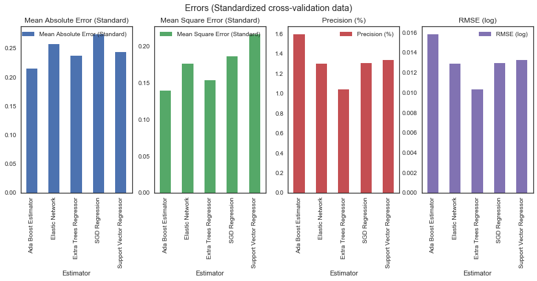

| Metric Estimator | Mean Absolute Error (Standard) | Mean Square Error (Standard) | Precision (%) | RMSE (log) |
| --- | --- | --- | --- | --- |
| Ada Boost Estimator | 0.214370 | 0.138883 | 1.594400 | 0.015808 |
| Elastic Network | 0.257416 | 0.175564 | 1.295390 | 0.012856 |
| Extra Trees Regressor | 0.237041 | 0.153585 | 1.039675 | 0.010305 |
| SGD Regression | 0.274000 | 0.186309 | 1.303217 | 0.012910 |
| Support Vector Regressor | 0.243421 | 0.216046 | 1.338326 | 0.013270 |

```python
prediction_result_numerical = predict_and_plot_cv(
    # The data to fit
    X = standard_X[list(numerical_cols - {'SalePrice', 'Id'})],
    Y = standard_Y,
    # The estimators
    estimators_list = estimators_list,
    # The metrics
    metrics_list = metrics_list
)

# Display the results
prediction_result_numerical
```

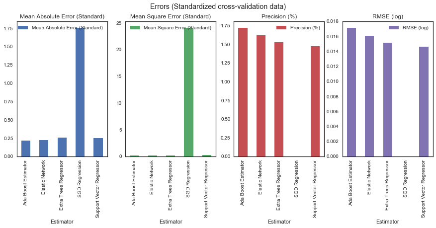

| Metric Estimator | Mean Absolute Error (Standard) | Mean Square Error (Standard) | Precision (%) | RMSE (log) |
| --- | --- | --- | --- | --- |
| Ada Boost Estimator | 0.215339 | 0.137689 | 1.719420 | 0.017125 |
| Elastic Network | 0.222521 | 0.146263 | 1.618467 | 0.016048 |
| Extra Trees Regressor | 0.254425 | 0.182185 | 1.528317 | 0.015123 |
| SGD Regression | 1.755888 | 24.068065 | NaN | NaN |
| Support Vector Regressor | 0.251532 | 0.247884 | 1.472274 | 0.014584 |

```python
prediction_result = predict_and_plot_cv(
    # The data to fit
    X = standard_X, Y = standard_Y,
    # The estimators
    estimators_list = estimators_list,
    # The metrics
    metrics_list = metrics_list
)

# Display the results
prediction_result
```

Please note that the RMSE(log) for the SGD is so high that the returned value is NaN.

### Features selection

- f_regression : F-value between label/feature for regression tasks.
- mutual_info_regression : Mutual information for a continuous target.

```python
from sklearn.feature_selection import SelectKBest
from sklearn.feature_selection import f_regression, mutual_info_regression

nb_features = 100

fs = SelectKBest(mutual_info_regression, k=nb_features)
fs.fit(standard_X, standard_Y)
new_features = fs.get_support()

df_feature_select = standard_X.drop(
    columns=standard_X.columns[~new_features]
)

assert len(df_feature_select.columns) == nb_features, "The number of features is not the selected one!"
```

The code to visualize it (not necessary at this point):

```
for feature_name in df_feature_select.columns[:5]:
    fig, ax = plt.subplots(figsize=(15, 3))
    ax.set_title(feature_name)
    ax.set_xlabel('Feature')
    ax.set_ylabel('Median house value')
    plt.scatter(df_feature_select[feature_name],standard_Y)
```

#### Predict with the selected features

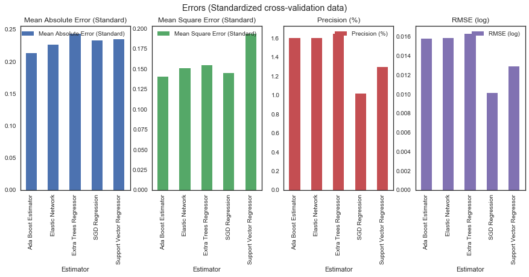

| Metric Estimator | Mean Absolute Error (Standard) | Mean Square Error (Standard) | Precision (%) | RMSE (log) |
| --- | --- | --- | --- | --- |
| Ada Boost Estimator | 0.213110 | 0.140447 | 1.596713 | 0.015807 |
| Elastic Network | 0.226688 | 0.150738 | 1.596235 | 0.015831 |
| Extra Trees Regressor | 0.243197 | 0.154260 | 1.643859 | 0.016284 |
| SGD Regression | 0.232667 | 0.144589 | 1.016727 | 0.010096 |
| Support Vector Regressor | 0.234802 | 0.193472 | 1.296995 | 0.012878 |

```python
prediction_result_selected = predict_and_plot_cv(
    # The data to fit
    X = df_feature_select,
    Y = standard_Y,
    # The estimators
    estimators_list = estimators_list,
    # The metrics
    metrics_list = metrics_list
)

prediction_result_selected
```

## Custom estimator based on previous results

Both of these estimators are good and estimating different things: SGD is good at fitting the most valuable elements where trees dive into the details (such as pools, ...) looking for valuable differences.  
To take advantage of both, and reduce the risk of overfitting, we use them now as weak learners to build a super learner. The aggregation method can be the mean or a single percetron using the identity function as the activation function.

```python
from sklearn.base import BaseEstimator

class CustomEstimator(BaseEstimator):

    def __init__(self, nb_sgd_features=50):
        """
            This estimator mixes a regular regression with SGD and
            also uses trees to predict.
            The `nb_sgd_features` is used to perform the
            feature selection used for the sgd regressor to be efficient.
        """
        self.nb_sgd_features = nb_sgd_features
        # SGD for feature selection data
        self.SGDest = SGDRegressor(loss='squared_loss', penalty='l2',  random_state=33)
        # Random forest for the whole set
        self.ETRest = ExtraTreesRegressor(n_estimators=10,random_state=33,n_jobs=8)

    def feature_select(self, X, y):
        """
            Returns the support of the feature selection.
        """
        fs = SelectKBest(mutual_info_regression, k=self.nb_sgd_features)
        fs.fit(X, y)
        return fs.get_support()

    def fit(self, X, y):
        self.selection_support = self.feature_select(X, y)
        self.SGDest.fit(X.iloc[:,self.selection_support], y)
        self.ETRest.fit(X, y)
        return self

    def predict(self, X, y=None):
        resultSGD = self.SGDest.predict(X.iloc[:,self.selection_support])
        resultETR = self.ETRest.predict(X)
        return np.array([(resultSGD[i] + resultETR[i])/2 for i in range(len(X))])
```

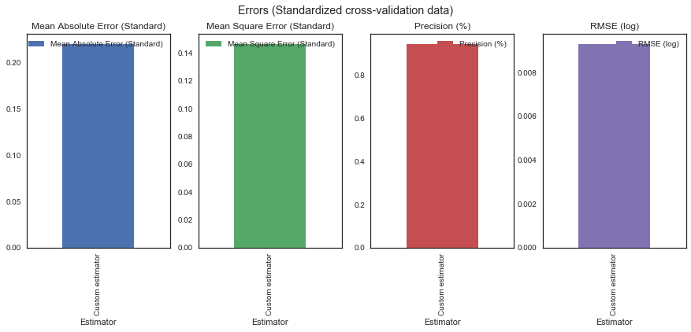

| Metric Estimator | Mean Absolute Error (Standard) | Mean Square Error (Standard) | Precision (%) | RMSE (log) |
| --- | --- | --- | --- | --- |
| Custom estimator | 0.220207 | 0.146336 | 0.944899 | 0.00929 |

```python
Custestimator = CustomEstimator()

prediction_result_custom = predict_and_plot_cv(
    # The data to fit
    X = standard_X,
    Y = standard_Y,
    # The estimator
    estimators_list = [{"name":"Custom estimator", "function":Custestimator}],
    # The metrics
    metrics_list = metrics_list
)
prediction_result_custom
```

**Note on the prediction results**

Here the precision that we get may suggest tha we overfit the trainingset a little bit due to the preprocessing steps as explained earlier. The training set is more homogeneous that it was and therefore the crossvalidation fails to completely prevent overfitting. Also, as explained earlier, this is a choice that aims to predict perfectly average houses, and a little bit less accurately the ones that costs a lot.  
However, due to the latent factors of expensive houses, they should not be very much underpriced.

Reminder

The prices is this dataset are set by a human and not automaticaly. Therefore there is a noise to this measure (the price is one). Thus, it is impossible to predict prices with an error of zero. Predicting results with a 10% precision is already an excellent result. Predicting prices below 5% of precision is almost impossible, with regard of the own margin of error of the person that prices the house, the trends of the housing market and the price expectations of the seller.

## Test data processing

```python
test_data = pd.read_csv("challenge_data/test.csv", index_col="Id")

for col in test_data.columns:
    test_data[col] = test_data[col].astype(dtype=training_data[col].dtype)

categorical_cols = set(training_data.columns) - numerical_cols
numerical_cols_test = numerical_cols - {"SalePrice"}

test_data.head()
```

| Id | MSSubClass | MSZoning | LotFrontage | LotArea | Street | Alley | LotShape | LandContour | Utilities | LotConfig | ... | ScreenPorch | PoolArea | PoolQC | Fence | MiscFeature | MiscVal | MoSold | YrSold | SaleType | SaleCondition |
| --- | --- | --- | --- | --- | --- | --- | --- | --- | --- | --- | --- | --- | --- | --- | --- | --- | --- | --- | --- | --- | --- |
| 1201 | 20 | RL | 71.0 | 9353 | Pave | NaN | Reg | Lvl | AllPub | Inside | ... | 0 | 0 | NaN | NaN | Shed | 0 | 7 | 2006 | Oth | Abnorml |
| 1202 | 60 | RL | 80.0 | 10400 | Pave | NaN | Reg | Lvl | AllPub | Corner | ... | 0 | 0 | NaN | NaN | NaN | 0 | 3 | 2009 | WD | Normal |
| 1203 | 50 | RM | 50.0 | 6000 | Pave | NaN | Reg | Lvl | AllPub | Corner | ... | 0 | 0 | NaN | NaN | NaN | 0 | 5 | 2009 | WD | Normal |
| 1204 | 20 | RL | 75.0 | 9750 | Pave | NaN | Reg | Lvl | AllPub | Inside | ... | 0 | 0 | NaN | NaN | NaN | 0 | 10 | 2009 | WD | Normal |
| 1205 | 20 | RL | 78.0 | 10140 | Pave | NaN | Reg | Lvl | AllPub | Inside | ... | 0 | 0 | NaN | MnPrv | NaN | 0 | 7 | 2006 | WD | Normal |

5 rows × 79 columns

```python
def change_type(col):
    """
        Apply training types to test dataframe to keep the same categories
    """
    return col.astype(training_data.dtypes.to_dict().get(col.name))

test_data = test_data.apply(change_type, axis=0)
```

### Fill the unknown values

Here we display the features with more than 10% of missing values.

```python
nans = pd.isnull(test_data).sum()/len(test_data)
nans[nans > .1]
```

```
LotFrontage    0.188462
Alley          0.938462
FireplaceQu    0.484615
PoolQC         0.988462
Fence          0.792308
MiscFeature    0.976923
dtype: float64
```

We decided to fill the nan values accordingly to the mean (or the most frequent value) of the training values grouped by Neigborhood.

We could also replace Na values using the nearests neighbors in the training with respect to the numerical values, aggregating them by mean/median value for numerical values and the most frequent value for the categorical values. This is much more complicated and tunable as this require to setup a metric that process categorical data, and multicaled numerical data.  
(this is the topic of this [issue](https://github.com/pandas-dev/pandas/issues/9471) on the pandas github)

```python
from collections import Counter
from functools import partial

def isnan(x):
    if type(x) == str:
        return False
    return np.isnan(x)

def categorical_aggregation(values, placeholder_dict):
    """
        Aggregation function for numerical values
        input:  pandas series,
            placeholder_dict is the replacement value
            when no available value
        output: most frequent value once nan are removed
    """
    counter = Counter(values)
    try:
        if isnan(counter.most_common(1)[0][0]):
            del counter[float("nan")]
        return counter.most_common(1)[0][0]
    except IndexError:
        # In case of a null Counter, a global replacement is performed
        return placeholder_dict(values.name)
```

```python
# In case a neighborhood is not found, a global
# (but less accurate) aggregation is processed
global_replacement = {col:
    np.mean(training_data[col])
    if col in numerical_cols_test else
    # Custom aggregation for categorical data
    categorical_aggregation(training_data[col],
                            placeholder_dict=lambda x: float("nan"))
    for col in test_data.columns
}

agg_dict = {col:
    # Mean aggregation for numerical values
    np.mean
    if col in numerical_cols_test else
    # Custom aggregation for categorical data
    partial(categorical_aggregation,
    # Use the global aggregation for not found values
            placeholder_dict=global_replacement.get)
    for col in test_data.columns
}


replacement_neighborhood = (training_data
    #Group by neighborhood as this is a almost the main criteria
    #in real life price setting
    .groupby("Neighborhood")
    # Aggregating as defined above
    .agg(agg_dict, raw=True)
)
```

Now we are ready to replace missing values

```python
vect_isnan = np.vectorize(isnan)

def replace_nan(row):
    """
        Replace nan row-wise
    """
    if row.Neighborhood in replacement_neighborhood.index:
        replacement_values = replacement_neighborhood.loc[row.Neighborhood].to_dict()
    else:
        replacement_values = global_replacement
    for col in row[vect_isnan(row)].index:
        row[vect_isnan(row)][col] = replacement_values[col]
    return row

# Interpolate the values for which there is no replacement data.
test_data = test_data.apply(replace_nan, axis=1).interpolate(method="nearest")
```

### Preprocess data

```python
dummies = [pd.get_dummies(test_data[col_name], prefix=col_name)
           for col_name in categorical_cols]

test_ready_data = pd.concat([test_data[list(numerical_cols - {"SalePrice"})]] + dummies, axis=1)
```

Adding missing columns (dummy variables not present in the training set) in order to scale them (standardization)

Note that because these are dummy variables we can set them to zero without adding a bias to our prediction

```python
for col in (set(preprocessed_data_X.columns)
    - set(test_ready_data.columns)):
    test_ready_data[col] = 0
```

```python
standard_test_X = pd.DataFrame(
    # Remove the dummy variables that we haven't seen in the training
    # (We can't predict accurately on them)
    scalerX.transform(test_ready_data[preprocessed_data_X.columns.tolist()]),
    columns=preprocessed_data_X.columns
)
```

### Fit the model and predict the test data

```python
from sklearn.base import clone

def predict_and_test(
    # training data
    X_train, Y_train,
    # test data
    X_test,
    # estimation functions (see sklearn doc)
    estimator):

    # Do not use the original estimator to not bias its weights
    estimator = clone(estimator)

    # Then fit and predict
    estimator.fit(X_train, Y_train)

    return estimator.predict(X_test)
```

```python
production_estimator = CustomEstimator()

results = predict_and_test(standard_X, standard_Y,
                           standard_test_X,
                           production_estimator)
results = inverse_y(results)
```

### Save the results

```python
formated_results = pd.DataFrame({"Id":standard_test_X.index, "SalePrice":results})
formated_results.set_index("Id", inplace=True)
formated_results.to_csv("submission.csv")
```

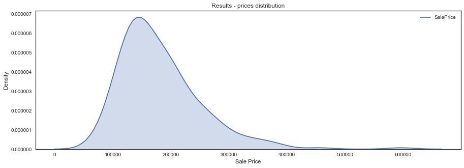

```python
plt.figure(figsize=(15, 5))

sns.kdeplot(
    formated_results.SalePrice,
    shade=True
)

plt.title("Results - prices distribution")
plt.xlabel("Sale Price")
plt.ylabel("Density")
plt.show()
```

## Improvements

### Performances improvements suggestions

#### Use distributed calculus libraries

[`Dask`](https://dask.pydata.org) is the native Python equivalent to `Spark` in Scala, and also includes all the features of `sklearn`, `numpy` and `pandas`, using `xarray` objects (a mix of a numpy array and a pandas dataframe). Therefore this is the perfect candidate to perform distributed operations to this notebook, without a lot of changes within the code.

#### Use GPU-accelerated tensor libraries

As both of the method used (Regression parameter tuned by gradient descend and tree based regressor) are highly paralelizable, we could take advantage of this using the PyTorch library for which the numpy integration is the most achieved.  
The [`skorch`](https://github.com/dnouri/skorch) project is aiming to provide a full support of sklearn features, using PyTorch GPU acceleration.

### Use of probabilistic methods

Not very used in production nowadays, those methods are nevertheless very efficient and also give the degree of confidance into the model itself, which is good. However, Gaussian porcesses lose efficiency in high dimentionnal spaces, which is the the case here. Therefore we also have to process a feature selection as done before on the data.

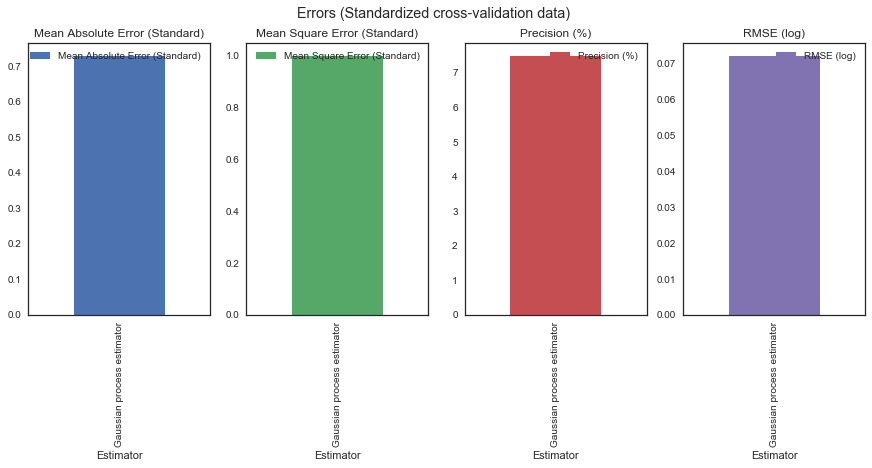

| Metric Estimator | Mean Absolute Error (Standard) | Mean Square Error (Standard) | Precision (%) | RMSE (log) |
| --- | --- | --- | --- | --- |
| Gaussian process estimator | 0.728027 | 0.996302 | 7.486831 | 0.072001 |

```python
from sklearn.gaussian_process import GaussianProcessRegressor

GPestimator = GaussianProcessRegressor(random_state=323)

prediction_result_custom = predict_and_plot_cv(
    # The data to fit
    X = df_feature_select,
    Y = standard_Y,
    # The estimator
    estimators_list = [{"name":"Gaussian process estimator", "function":GPestimator}],
    # The metrics
    metrics_list = metrics_list
)
prediction_result_custom
```

### Use Grid Search to tune the estimator parameters

Grid search is useful for estimating the best fitting hyper parameters to give to the estimators. There are the exhaustive one (which lead to a heavy overhead in terms of computation due to the need to train and validate the model multiple times) and the random one, which is less accurate but way less demanding.  
In our case, tuning our custom estimator would increase even more the overfitting, and it is therefore not advisable to do it.

## References

- [Notes on the dataset](https://ww2.amstat.org/publications/jse/v19n3/decock.pdf)
- [A simple regression model for real estate](https://gallery.azure.ai/Experiment/Building-a-Regression-Model-to-Predict-Real-Estate-Sales-Price-1)
- [Dummy variables](https://www.coursera.org/learn/linear-regression-business-statistics/lecture/6bzpf/categorical-variables-in-a-regression-dummy-variables)
- [Latent model analysis](https://en.wikipedia.org/wiki/Mixture_model)
- [MS Azure reference over normalization process](https://docs.microsoft.com/en-us/azure/machine-learning/studio-module-reference/normalize-data)
- [Grid search](http://scikit-learn.org/stable/modules/grid_search.html)